# NBA Winning Factors Analysis

Nathan Jean-Packard

# Introduction

I have long been interested in the NBA and so I decided to run an analysis on which common statistics most influence winning in the NBA. To do this I used a data set from Kaggle containing the box score of every NBA game from 1947 until present. I then ran three different models (logistic regression, decision tree, and random forest) in order to:

1. Measure how different stats affect the chances of winning.
2. Figure out which model is best at predicting wins.

To narrow the scope I decided to focus the analysis on games from 2016 to 2026 that reflect the modern NBA game.

## Getting Started

To start we have to load the required libraries that will be used for creating the models and visualizations and load in the data set. The data set is then filtered to include only games from 2016 onward, and only variables that will be used in the analysis are kept. Rows with missing values are removed for consistency.

```r
# Load Libraries
library(tidyverse)
library(pROC)
library(ResourceSelection)
library(caret)
library(randomForest)
library(corrplot)
library(rpart)
library(rpart.plot)

# Load Dataset
team_stats <- read.csv("TeamStatistics.csv")

# Create vector of the variables of interest
vars <- c("win", "fieldGoalsAttempted", "fieldGoalsPercentage",
          "threePointersAttempted", "threePointersPercentage",
          "freeThrowsAttempted", "freeThrowsPercentage", "turnovers",
          "reboundsTotal", "pointsInThePaint", "pointsSecondChance", "pointsFastBreak")

# Look only at data going back to 2016 where none of the variables of interest are missing
team_stats_clean <- team_stats %>%
  filter(gameDate >= as.Date("2016-01-01")) %>%
  select(all_of(vars)) %>%
  filter(complete.cases(.))
```

## Exploratory Analysis

### Box Plots

With the data loaded and cleaned up we can explore how each variable differs between wins and losses. To do this we create box plots for each predictor variable. The resulting box plots below show clear separation between wins and losses for several variables and very little separation for others. In particular, field goal percentage, three-point percentage, and total rebounds show the largest differences suggesting that they may be strong predictors of game outcome. Field goals attempted and three-pointers attempted on the other hand had very little difference between wins and losses.

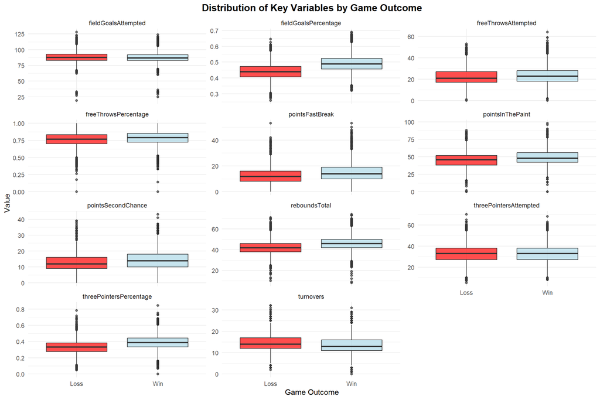

```r
# Reshape data to long format
team_stats_long <- team_stats_clean %>%
  mutate(win = factor(win, labels = c("Loss", "Win"))) %>%
  pivot_longer(
    cols = -win,
    names_to = "variable",
    values_to = "value")

# Create Boxplot
ggplot(team_stats_long, aes(x = factor(win), y = value, fill = factor(win))) +
  geom_boxplot(alpha = 0.7) +
  facet_wrap(~ variable, scales = "free_y", ncol = 3) +
  scale_fill_manual(values = c("Loss" = "red", "Win" = "lightblue")) +
  labs(title = "Distribution of Key Variables by Game Outcome",
       x = "Game Outcome",
       y = "Value",
       fill = "Outcome") +
  theme_minimal() +
  theme(plot.title = element_text(hjust = 0.5, size = 14, face = "bold"),
        strip.text = element_text(size = 9),
        legend.position = "none")
```

### Correlation Heatmap

Next we can look at how each of the variables are correlated in order to check for multicollinearity and which variables most correlate with winning. Below is the correlation matrix for the data. There are some predictor variables that show some correlation, field goal percentage and three point percentage being 0.54 is one example, but it is low enough that I will keep all the variables in the analysis.

We can also look at the top row and see which variables have the highest correlation with wins. Field goal percentage is the most correlated with winning, followed by three point percentage, and total rebounds.

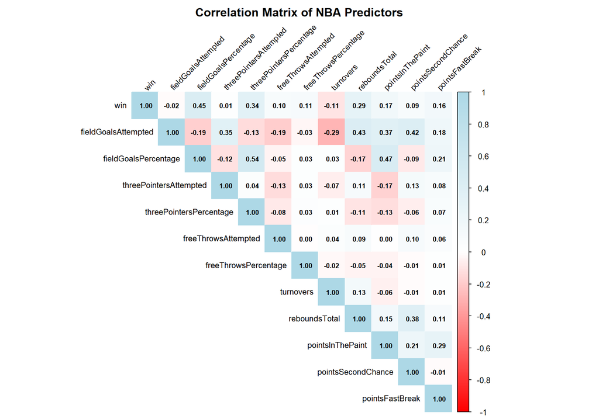

```r
# Calculate correlation matrix
cor_matrix <- cor(team_stats_clean, use = "complete.obs")

# Create correlation heatmap
corrplot(cor_matrix,
         method = "color",
         type = "upper",
         tl.col = "black",
         tl.srt = 45,
         tl.cex = 0.8,
         addCoef.col = "black",
         number.cex = 0.7,
         col = colorRampPalette(c("red", "white", "lightblue"))(200),
         title = "Correlation Matrix of NBA Predictors",
         mar = c(0, 0, 2, 0))
```

# Models

We will now get into the different models that will be used for this analysis. For each of the models we will be considering the same variables affect on win probability: field goal attempts, field goal percentage, three-point attempts, three-point percentage, free throw attempts, free throw percentage, turnovers, total rebounds, points in the paint, fast break points, and second chance points. While there are many other variables that could be included, these variables were selected to represent things like shooting efficiency, ball security, rebounding, and scoring at different levels.

The three models we will use are logistic regression, decision tree, and random forest. We can then compare the results from each and determine which model is best at predicting NBA wins.

## Splitting the Data

To evaluate model performance, the data set will be split into training and testing subsets. The training data is used to fit and refine each model, while the testing data is held back and used to assess how well each model does when presented with new data.

```r
# Define model formula
model_formula <- win ~ fieldGoalsAttempted + fieldGoalsPercentage +
                       threePointersAttempted + threePointersPercentage +
                       freeThrowsAttempted + freeThrowsPercentage +
                       turnovers + reboundsTotal + pointsInThePaint +
                       pointsSecondChance + pointsFastBreak

# Ensure win is treated as a categorical variable for classification
team_stats_clean$win <- as.factor(team_stats_clean$win)

# Reproducible random number
set.seed(25)

# Partition the data to train and test with 80% training and 20% testing
train_index <- createDataPartition(team_stats_clean$win, p = 0.8, list = FALSE)
train_data <- team_stats_clean[train_index, ]
test_data  <- team_stats_clean[-train_index, ]
```

## Logistic Regression Model

Logistic regression is a statistical model that predicts the probability of a binary event, such as win/loss, occurring. From this model we see that increasing field goal percentage has by far the largest positive effect on win probability, with three pointer percentage, and free throw percentage also having positive effects. Unsurprisingly, turnovers has a negative effect on the probability of winning. What may seem surprising is that field goal attempts has a slight negative relationship as well. This is likely because field goal attempts and field goal percentage are inherently related, percentage being derived from attempts, causing the negative coefficient for attempts.

```r
# Create logistic regression model
logistic_model <- glm(model_formula,
             data = train_data,
             family = binomial)

summary(logistic_model)
```

```
##
## Call:
## glm(formula = model_formula, family = binomial, data = train_data)
##
## Coefficients:
##                           Estimate Std. Error z value Pr(>|z|)
## (Intercept)             -20.757482   0.534488 -38.836  < 2e-16 ***
## fieldGoalsAttempted      -0.096200   0.004735 -20.315  < 2e-16 ***
## fieldGoalsPercentage     32.390572   0.777615  41.654  < 2e-16 ***
## threePointersAttempted    0.023091   0.002947   7.835 4.70e-15 ***
## threePointersPercentage   4.554203   0.340267  13.384  < 2e-16 ***
## freeThrowsAttempted       0.028391   0.002952   9.618  < 2e-16 ***
## freeThrowsPercentage      3.444978   0.199572  17.262  < 2e-16 ***
## turnovers                -0.225058   0.006063 -37.119  < 2e-16 ***
## reboundsTotal             0.272359   0.004765  57.163  < 2e-16 ***
## pointsInThePaint         -0.023729   0.003457  -6.865 6.65e-12 ***
## pointsSecondChance        0.022512   0.004067   5.535 3.12e-08 ***
## pointsFastBreak           0.031154   0.003282   9.494  < 2e-16 ***
## ---
## Signif. codes:  0 '***' 0.001 '**' 0.01 '*' 0.05 '.' 0.1 ' ' 1
##
## (Dispersion parameter for binomial family taken to be 1)
##
##     Null deviance: 27598  on 19907  degrees of freedom
## Residual deviance: 16177  on 19896  degrees of freedom
## AIC: 16201
##
## Number of Fisher Scoring iterations: 5
```

### Logistic Regression Confusion Matrix

The confusion matrix compares predicted outcomes to actual results. Model accuracy is approximately 81% with a confidence interval from 79.56% to 81.78%, well above the 50% you’d get with random guessing. The logistic regression also does equally well with predicting wins (81.15%) as it does loses (80.23%).

```r
# Calculate predicted win probability
pred_probs <- predict(logistic_model, newdata = test_data, type = "response")

# If probability is greater than 0.5 predict win, else predict loss
pred_class <- ifelse(pred_probs > 0.5, 1, 0)

# Confusion Matrix of correct and incorrect predictions
confusionMatrix(
  factor(pred_class),
  factor(test_data$win)
)
```

```
## Confusion Matrix and Statistics
##
##           Reference
## Prediction    0    1
##          0 1996  469
##          1  492 2019
##
##                Accuracy : 0.8069
##                  95% CI : (0.7956, 0.8178)
##     No Information Rate : 0.5
##     P-Value [Acc > NIR] : <2e-16
##
##                   Kappa : 0.6137
##
##  Mcnemar's Test P-Value : 0.4779
##
##             Sensitivity : 0.8023
##             Specificity : 0.8115
##          Pos Pred Value : 0.8097
##          Neg Pred Value : 0.8041
##              Prevalence : 0.5000
##          Detection Rate : 0.4011
##    Detection Prevalence : 0.4954
##       Balanced Accuracy : 0.8069
##
##        'Positive' Class : 0
##
```

## Decision Tree

Next, we will look at the decision tree model. This model makes predictions by splitting the data into branches based on different conditions. It creates an easy to understand visual, but is sensitive to small variations in data. Below is the resulting decision tree.

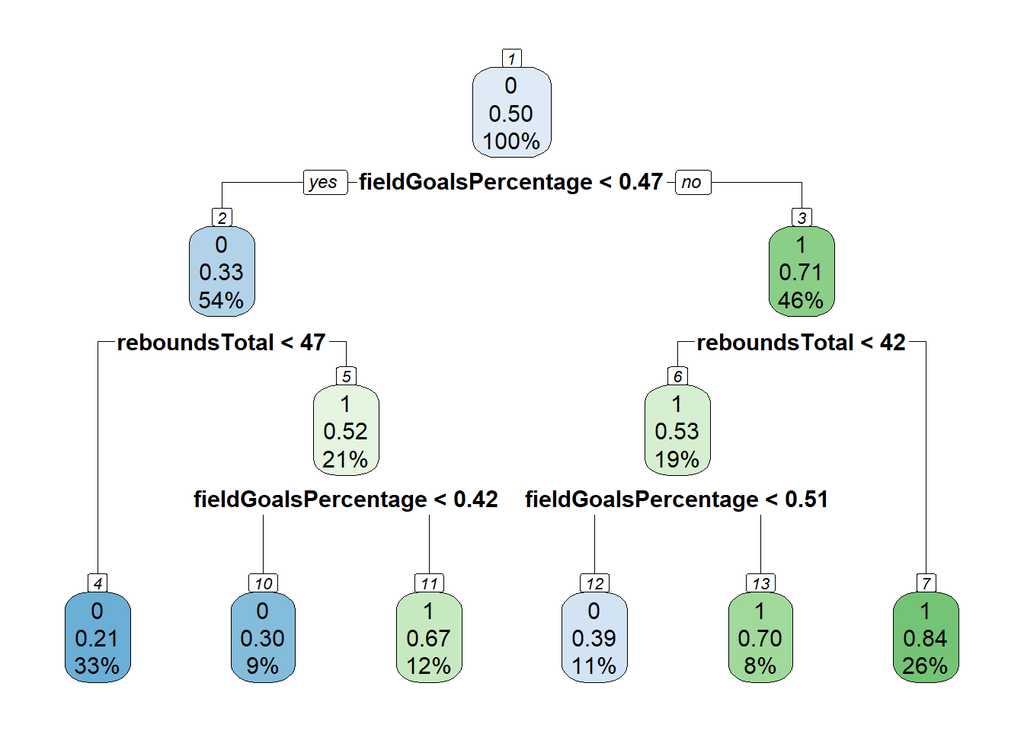

```r
# Create decision tree
decision_tree <- rpart(model_formula,
                    data = train_data,
                    method = "class",  # For classification
                    control = rpart.control(minsplit = 20, cp = 0.01))

# Plot decision tree
rpart.plot(decision_tree, box.palette = "auto", nn = TRUE)
```

### Decision Tree Confusion Matrix

The confusion matrix for the decision tree is accurate about 75% of the time with a confidence interval of 74.22% to 76.63%. It is slightly better at predicting losses (77.97%) than it is wins (72.91%).

```r
# Decision tree predictions based on testing data
dtpredictions <- predict(decision_tree, test_data, type = "class")
confusionMatrix(dtpredictions, test_data$win)
```

```
## Confusion Matrix and Statistics
##
##           Reference
## Prediction    0    1
##          0 1940  674
##          1  548 1814
##
##                Accuracy : 0.7544
##                  95% CI : (0.7422, 0.7663)
##     No Information Rate : 0.5
##     P-Value [Acc > NIR] : < 2.2e-16
##
##                   Kappa : 0.5088
##
##  Mcnemar's Test P-Value : 0.0003491
##
##             Sensitivity : 0.7797
##             Specificity : 0.7291
##          Pos Pred Value : 0.7422
##          Neg Pred Value : 0.7680
##              Prevalence : 0.5000
##          Detection Rate : 0.3899
##    Detection Prevalence : 0.5253
##       Balanced Accuracy : 0.7544
##
##        'Positive' Class : 0
##
```

## Random Forest

Finally, we will look at the random forest model. Random forests are made up by combining the results of many decision trees. Since a single decision tree can be affected by variations in the data and the sample it was created from, random forests mitigate that problem by aggregating the results of many decision trees. Below is the confusion matrix of the training data, but it is better to judge the model’s performance on results from the testing data. We do get an OOB (out of bag) error rate of 20.32% which should be similar to the rate we see from the testing data.

```r
# Create random forest
random_forest <- randomForest(model_formula,
                              data=train_data)
# Results from training data
print(random_forest)
```

```
##
## Call:
##  randomForest(formula = model_formula, data = train_data)
##                Type of random forest: classification
##                      Number of trees: 500
## No. of variables tried at each split: 3
##
##         OOB estimate of  error rate: 20.32%
## Confusion matrix:
##      0    1 class.error
## 0 7945 2009   0.2018284
## 1 2036 7918   0.2045409
```

### Random Forest Confusion Matrix

The confusion matrix for the random forest is accurate about 80% of the time with a confidence interval of 78.6% to 80.85%. It performs about equal for wins(80.31%) and losses (79.18%).

```r
# Results from testing data
rfpredictions <- predict(random_forest, test_data)
confusionMatrix(rfpredictions, test_data$win)
```

```
## Confusion Matrix and Statistics
##
##           Reference
## Prediction    0    1
##          0 1970  490
##          1  518 1998
##
##                Accuracy : 0.7974
##                  95% CI : (0.786, 0.8085)
##     No Information Rate : 0.5
##     P-Value [Acc > NIR] : <2e-16
##
##                   Kappa : 0.5949
##
##  Mcnemar's Test P-Value : 0.3951
##
##             Sensitivity : 0.7918
##             Specificity : 0.8031
##          Pos Pred Value : 0.8008
##          Neg Pred Value : 0.7941
##              Prevalence : 0.5000
##          Detection Rate : 0.3959
##    Detection Prevalence : 0.4944
##       Balanced Accuracy : 0.7974
##
##        'Positive' Class : 0
##
```

### Random Forest Variable Importance

Below are what the random forest determined to be the most important variables, field goal percentage, total rebounds, and three-point percentage. This matches what we saw in the exploratory analysis with those variables having the largest difference among the box plots and being the most correlated.

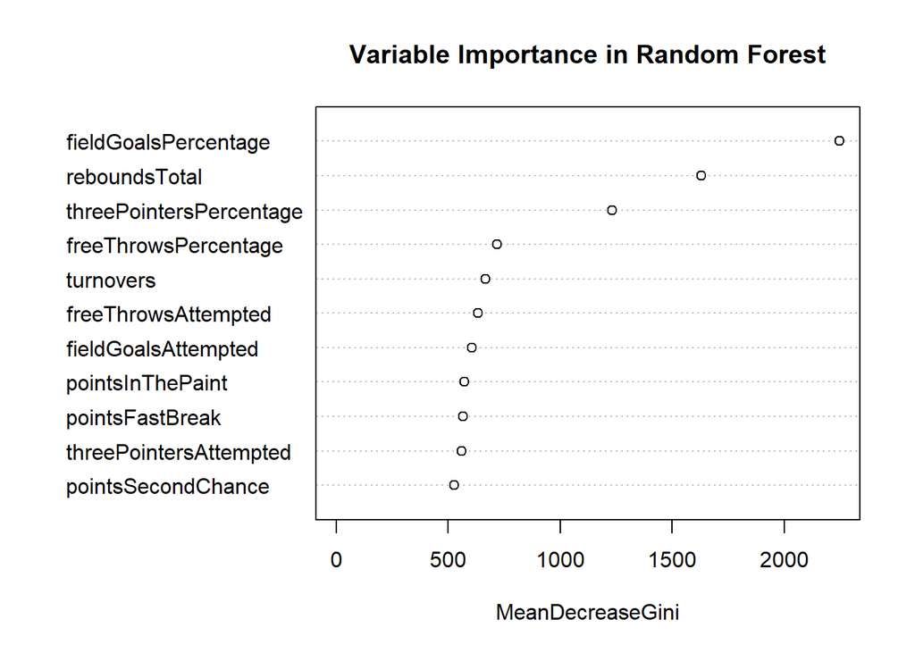

```r
# Create a dotchart of variable importance
varImpPlot_forest <- varImpPlot(random_forest, main = "Variable Importance in Random Forest")
```

```r
varImpPlot_forest
```

```
##                         MeanDecreaseGini
## fieldGoalsAttempted             606.8142
## fieldGoalsPercentage           2248.2117
## threePointersAttempted          560.4568
## threePointersPercentage        1231.0251
## freeThrowsAttempted             631.7551
## freeThrowsPercentage            716.9599
## turnovers                       666.4612
## reboundsTotal                  1628.8309
## pointsInThePaint                570.9266
## pointsSecondChance              525.5258
## pointsFastBreak                 565.5717
```

## ROC Curve

The ROC (Receiver Operating Characteristic) curve looks at the true positive rate compared to the false positive rate. The more the curve is to the top left the better the model is at categorizing data. The diagonal line represents 50% or in essence if predictions were a coin flip.

Logistic regression achieved the highest AUC (area under the curve) of 0.897, meaning the model has about an 89.7% probability of correctly predicting a win or loss. Then the random forest was close behind with an AUC of 0.884 or about an 88.4% chance and the decision tree was the worst with an AUC of 0.791 or about a 79.1% chance of correctly predicting a win or loss.

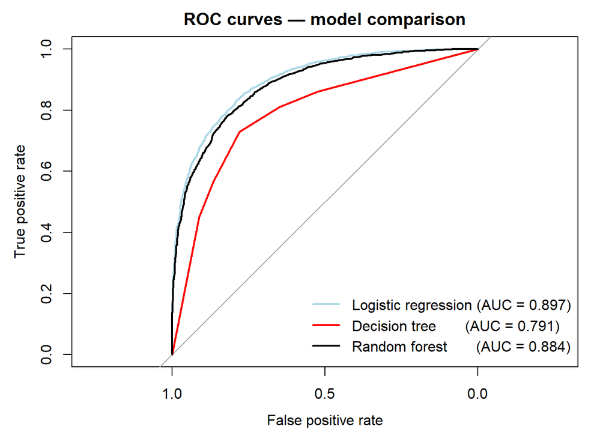

```r
# Logistic regression predictions
prob_lr   <- predict(logistic_model, newdata = test_data, type = "response")

# Decision tree predictions
prob_tree <- predict(decision_tree, newdata = test_data, type = "prob")[, 2]

# Random forest predictions
prob_rf   <- predict(random_forest, newdata = test_data, type = "prob")[, 2]

# Build ROC objects
roc_lr   <- roc(test_data$win, prob_lr)
roc_tree <- roc(test_data$win, prob_tree)
roc_rf   <- roc(test_data$win, prob_rf)

# Get AUC's
auc_lr   <- round(auc(roc_lr),   3)
auc_tree <- round(auc(roc_tree), 3)
auc_rf   <- round(auc(roc_rf),   3)

# Create ROC graph with all three curves on the same graph
plot(roc_lr,
     col       = "lightblue",
     lwd       = 2,
     main      = "ROC curves — model comparison",
     xlab      = "False positive rate",
     ylab      = "True positive rate")

plot(roc_tree, col = "red", lwd = 2, add = TRUE)
plot(roc_rf,   col = "black", lwd = 2, add = TRUE)

# Create legend
legend("bottomright",
       legend = c(
         paste0("Logistic regression (AUC = ", auc_lr,   ")"),
         paste0("Decision tree       (AUC = ", auc_tree, ")"),
         paste0("Random forest       (AUC = ", auc_rf,   ")")
       ),
       col = c("lightblue", "red", "black"),
       lwd = 2,
       bty = "n")
```

# Conclusion

What have we learned from all this? Well it may not be groundbreaking, but we learned that shooting efficiency, particularly field goal percentage, is the strongest predictor of winning in the modern NBA. Three-point shooting and rebounding also play significant roles. As for the models, the logistic regression produced the best results with the highest accuracy of 80.69% and the largest AUC of 0.897, while the random forest was not far behind and the decision tree performed the worst.

There are some limitations with this data. My analysis only includes basic team box score statistics and so doesn’t include more advanced metrics like true shooting percentage or offensive or defensive ratings. Other factors like home-court or opponent are not taken into account (maybe the biggest predictor of winning is playing the Wizards). Finally, it also does not take into account the players in the game. A further analysis could be done to predict winning based on information about the players on the court, like their counting stats, their player efficiency rating, etc.

Ultimately, while no model can fully capture everything that goes on in an NBA game what we can say is that it’s clear you can’t win if you can’t shoot.

## References

Moore, E. *Historical NBA data and player box scores* [Data set]. Kaggle. https://www.kaggle.com/datasets/eoinamoore/historical-nba-data-and-player-box-scores